# QAC307 Revisit

Kathleen Cimino

4/5/2022

This is a revisit of my QAC307 final now that I have actually taken a course on survival analysis and didn’t just teach myself how Kaplan-Meier curves worked at the last second because about 18% of my data was unexpectedly censored. While a better dataset (with more participants, information on meme literacy, and riddles that are more comparable to each other) would be ideal for revisiting my work on this final, I have not found a good excuse to try and recruit people to solve my riddles three. Instead, I am interested in how fitting a Cox PH model could potentially allow for me to attempt to control for the difference in difficulty between the riddles, and because a Cox PH model can also be fit using Bayesian methods.

First, it is important to check the assumptions of the Cox Proportional Hazards models, namely that the hazards are proportional.

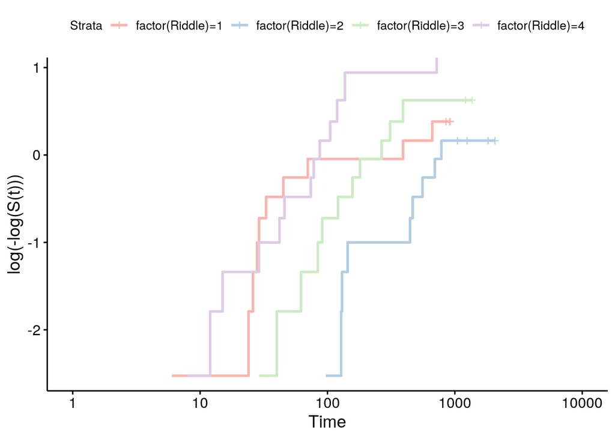

```r
mod1<- coxph(Surv(Time,Solved) ~ factor(Riddle) + factor(primed), data=data)
myfit1r<- survfit(Surv(Time,Solved) ~ factor(Riddle), data=data)
ggsurvplot(myfit1r, conf.int="FALSE", fun="cloglog", data=data, palette="Pastel1")
```

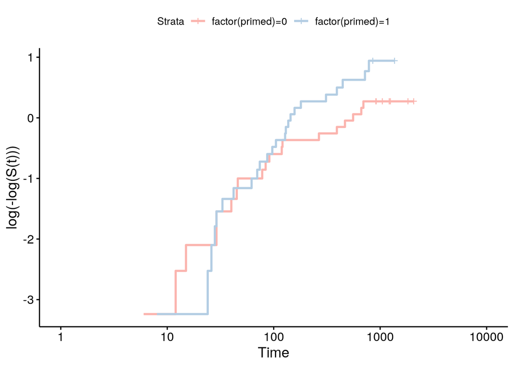

```r
myfit1p<- survfit(Surv(Time,Solved) ~factor(primed), data=data)
ggsurvplot(myfit1p, conf.int="FALSE", fun="cloglog", data=data, palette="Pastel1")
```

```r
cox.zph(mod1, transform="rank")
```

```
##                 chisq df     p
## factor(Riddle) 11.119  3 0.011
## factor(primed)  0.765  1 0.382
## GLOBAL         11.972  4 0.018
```

Riddle 1 clearly violates the PH assumptions. It is possible this is because of the size of the data set, or a poorly designed riddle (it’s the loss riddle, so that one benefited much more from prior knowledge than any other riddle). Because this analysis is being done for fun, I am going to simply remove Riddle 1 and retest the assumptions. If I were conducting this analysis for a class or project the appropriate solution would be to either conduct separate analyses on Riddle 1 and Riddles 2-4 or use a different model. There is also some cause for concern with the PH assumptions for the primed variable, but since there isn’t a super clear pattern, the violations are not statistically significant, and it’s such a small data set (and because this is not a serious analysis), I’m just going to leave it.

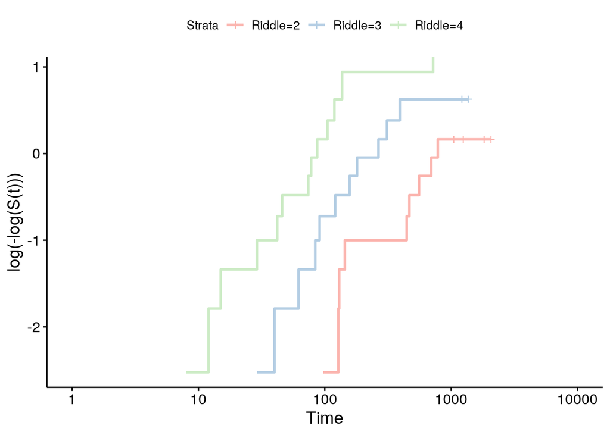

```r
df <- data %>% filter(Riddle > 1) %>% mutate(Riddle=as.factor(Riddle), primed=as.factor(primed))
mod1<- coxph(Surv(Time,Solved) ~ Riddle + primed, data=df)
myfit1r<- survfit(Surv(Time,Solved) ~ Riddle, data=df)
ggsurvplot(myfit1r, conf.int="FALSE", fun="cloglog", data=df, palette="Pastel1")
```

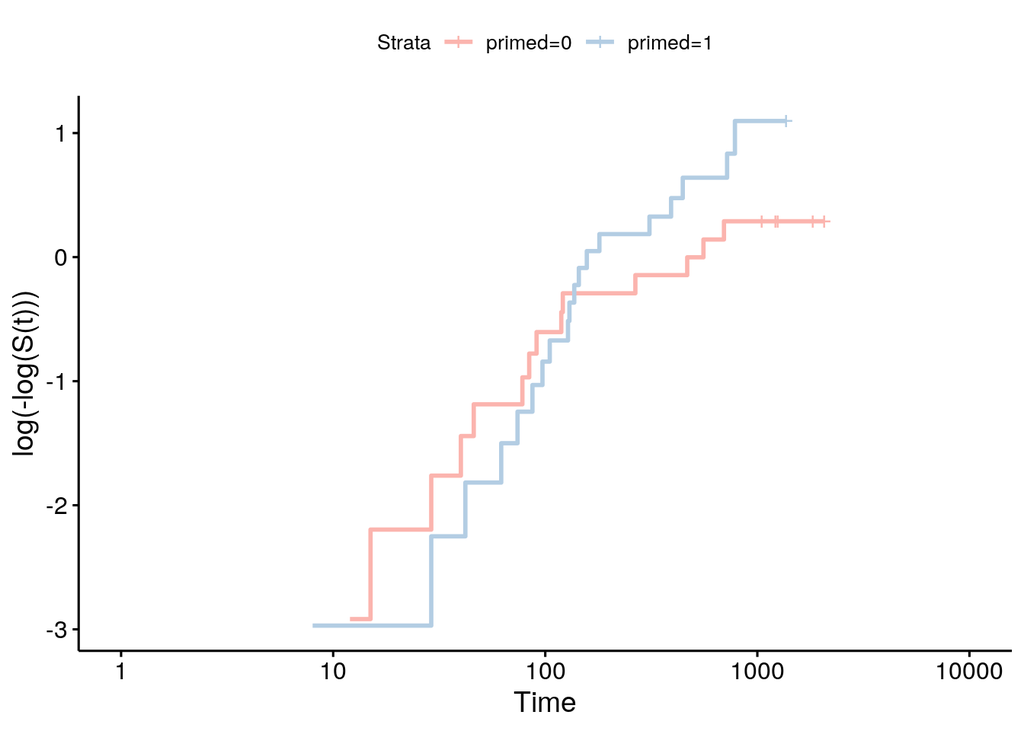

```r
myfit1p<- survfit(Surv(Time,Solved) ~primed, data=df)
ggsurvplot(myfit1p, conf.int="FALSE", fun="cloglog", data=df, palette="Pastel1")
```

```r
cox.zph(mod1, transform="rank")
```

```
##        chisq df     p
## Riddle  3.67  2 0.160
## primed  1.43  1 0.232
## GLOBAL  8.24  3 0.041
```

After removing Riddle 1, the PH assumptions of the riddles look fine. I am a little worried about the PH assumptions of the primed variable because the line for primed clearly crosses the line for not primed, but given the small data set it is difficult to tell if this is actually an issue.

```r
summary(mod1)
```

```
## Call:
## coxph(formula = Surv(Time, Solved) ~ Riddle + primed, data = df)
##
##   n= 39, number of events= 33
##
##             coef exp(coef) se(coef)      z Pr(>|z|)
## Riddle3  0.75960   2.13742  0.46882  1.620 0.105178
## Riddle4  1.74332   5.71628  0.49643  3.512 0.000445 ***
## primed1 -0.04893   0.95225  0.38596 -0.127 0.899126
## ---
## Signif. codes:  0 '***' 0.001 '**' 0.01 '*' 0.05 '.' 0.1 ' ' 1
##
##         exp(coef) exp(-coef) lower .95 upper .95
## Riddle3    2.1374     0.4679    0.8528     5.357
## Riddle4    5.7163     0.1749    2.1605    15.124
## primed1    0.9523     1.0501    0.4469     2.029
##
## Concordance= 0.706  (se = 0.039 )
## Likelihood ratio test= 14.18  on 3 df,   p=0.003
## Wald test            = 14.51  on 3 df,   p=0.002
## Score (logrank) test = 16.75  on 3 df,   p=8e-04
```

After controlling for Riddle, whether or not someone was primed is not statistically significant ($\hat{H}= 0.952$, p-value= .899). It is important to remember this is a small sample size and that there is some cause for concern with the assumptions of this model, so to know if there is actually not a relationship here both of those issues would need to be solved. This does, however, indicate that if I do ever redo this experiment I really need to test my riddles on people ahead of time. This conclusion is supported by the hazard (the probability that an event will occur given survival up to whatever time) of riddles 3 and 4 being much higher compared to riddle 2. The probability of someone solving the riddle given it is riddle 2 is 54% lower than riddle 3, and 83% lower than riddle 4.

## INLA

There are two major ways to do Bayesian analysis in R, one is to use JAGS (Just Another Gibbs Sampler) and the other is to use INLA (Integrated Nested Laplace Approximation). The INLA R package comes with survival functions built in that are very similar to those in the survival package.

I’m going to use a weakly informative prior because I have absolutely no idea what the distributions should be. In this particular scenario, the priors I use can actually affect the outcome more than usual because I have so few observations, so if I were doing a serious analysis I might need to be more careful about my priors. I’ll use the data from above removing the observations using Riddle 1 as the assumptions for the Cox PH remain the same for Bayesian analysis.

```r
library("INLA")
sinla.rid <- inla.surv(df$Time, df$Solved)

coxinla.rid <- inla(sinla.rid ~ 1  + as.factor(Riddle) + as.factor(primed), data = df,
  family = "coxph",
  control.hazard = list(hyper = list(prec = list(param = c(0.001, 0.001)))))
summary(coxinla.rid)
```

```
##
## Call:
##    c("inla.core(formula = formula, family = family, contrasts = contrasts,
##    ", " data = data, quantiles = quantiles, E = E, offset = offset, ", "
##    scale = scale, weights = weights, Ntrials = Ntrials, strata = strata,
##    ", " lp.scale = lp.scale, link.covariates = link.covariates, verbose =
##    verbose, ", " lincomb = lincomb, selection = selection, control.compute
##    = control.compute, ", " control.predictor = control.predictor,
##    control.family = control.family, ", " control.inla = control.inla,
##    control.fixed = control.fixed, ", " control.mode = control.mode,
##    control.expert = control.expert, ", " control.hazard = control.hazard,
##    control.lincomb = control.lincomb, ", " control.update =
##    control.update, control.lp.scale = control.lp.scale, ", "
##    control.pardiso = control.pardiso, only.hyperparam = only.hyperparam,
##    ", " inla.call = inla.call, inla.arg = inla.arg, num.threads =
##    num.threads, ", " blas.num.threads = blas.num.threads, keep = keep,
##    working.directory = working.directory, ", " silent = silent, inla.mode
##    = inla.mode, safe = FALSE, debug = debug, ", " .parent.frame =
##    .parent.frame)")
## Time used:
##     Pre = 3.39, Running = 3.52, Post = 0.124, Total = 7.04
## Fixed effects:
##                      mean    sd 0.025quant 0.5quant 0.975quant   mode  kld
## (Intercept)        -3.374 0.924     -5.682   -3.213     -2.049 -2.985 0.01
## as.factor(Riddle)3  0.593 0.471     -0.320    0.589      1.530  0.580 0.00
## as.factor(Riddle)4  1.177 0.483      0.252    1.169      2.150  1.153 0.00
## as.factor(primed)1  0.262 0.370     -0.452    0.259      0.999  0.251 0.00
##
## Random effects:
##   Name     Model
##     baseline.hazard RW1 model
##
## Model hyperparameters:
##                                 mean     sd 0.025quant 0.5quant 0.975quant
## Precision for baseline.hazard 448.24 455.79      32.60   299.69    1722.20
##                                mode
## Precision for baseline.hazard 94.76
##
## Marginal log-Likelihood:  -52.25
##  is computed
## Posterior summaries for the linear predictor and the fitted values are computed
## (Posterior marginals needs also 'control.compute=list(return.marginals.predictor=TRUE)')
```

As you can see, comparing riddle 2 to riddle 4 is again the only statistically significant explanatory variable. While the coeffiecients the INLA came up with differ slightly from those estimated by the frequentist method above, the above coefficients are all within the 95% confidence interval created by the INLA method.

If I needed data on the level of uncertainty of my model, the INLA method would be superior. If I just wanted to make a model and I had a lot of data, the frequentist method might be better because Bayesian analysis can be computationally expensive (although the INLA is much less computationally expensive than JAGS). Overall, doing survival analysis in INLA is about as easy as it is using the survival package, and if I ever try to revist the experiment itself I am absolutely going to find a meme for this.